# Regression with broom and dplyr

David Robinson

March 23, 2016

broom is a package for converting R model objects into “tidy” data frames that can be recombined, manipulated, and visualized using tools like dplyr and ggplot2.

Install it with:

```r
# install.packages("broom")
```

I’ll start by listing some worthwhile resources for dplyr and broom:

- [broom and dplyr vignette](https://cran.r-project.org/web/packages/broom/vignettes/broom_and_dplyr.html)
- [broom manuscript](http://arxiv.org/abs/1412.3565)

### mtcars data

The mtcars dataset comes built into R, and comes with information about 32 cars:

```r
mtcars
```

```
##                      mpg cyl  disp  hp drat    wt  qsec vs am gear carb
## Mazda RX4           21.0   6 160.0 110 3.90 2.620 16.46  0  1    4    4
## Mazda RX4 Wag       21.0   6 160.0 110 3.90 2.875 17.02  0  1    4    4
## Datsun 710          22.8   4 108.0  93 3.85 2.320 18.61  1  1    4    1
## Hornet 4 Drive      21.4   6 258.0 110 3.08 3.215 19.44  1  0    3    1
## Hornet Sportabout   18.7   8 360.0 175 3.15 3.440 17.02  0  0    3    2
## Valiant             18.1   6 225.0 105 2.76 3.460 20.22  1  0    3    1
## Duster 360          14.3   8 360.0 245 3.21 3.570 15.84  0  0    3    4
## Merc 240D           24.4   4 146.7  62 3.69 3.190 20.00  1  0    4    2
## Merc 230            22.8   4 140.8  95 3.92 3.150 22.90  1  0    4    2
## Merc 280            19.2   6 167.6 123 3.92 3.440 18.30  1  0    4    4
## Merc 280C           17.8   6 167.6 123 3.92 3.440 18.90  1  0    4    4
## Merc 450SE          16.4   8 275.8 180 3.07 4.070 17.40  0  0    3    3
## Merc 450SL          17.3   8 275.8 180 3.07 3.730 17.60  0  0    3    3
## Merc 450SLC         15.2   8 275.8 180 3.07 3.780 18.00  0  0    3    3
## Cadillac Fleetwood  10.4   8 472.0 205 2.93 5.250 17.98  0  0    3    4
## Lincoln Continental 10.4   8 460.0 215 3.00 5.424 17.82  0  0    3    4
## Chrysler Imperial   14.7   8 440.0 230 3.23 5.345 17.42  0  0    3    4
## Fiat 128            32.4   4  78.7  66 4.08 2.200 19.47  1  1    4    1
## Honda Civic         30.4   4  75.7  52 4.93 1.615 18.52  1  1    4    2
## Toyota Corolla      33.9   4  71.1  65 4.22 1.835 19.90  1  1    4    1
## Toyota Corona       21.5   4 120.1  97 3.70 2.465 20.01  1  0    3    1
## Dodge Challenger    15.5   8 318.0 150 2.76 3.520 16.87  0  0    3    2
## AMC Javelin         15.2   8 304.0 150 3.15 3.435 17.30  0  0    3    2
## Camaro Z28          13.3   8 350.0 245 3.73 3.840 15.41  0  0    3    4
## Pontiac Firebird    19.2   8 400.0 175 3.08 3.845 17.05  0  0    3    2
## Fiat X1-9           27.3   4  79.0  66 4.08 1.935 18.90  1  1    4    1
## Porsche 914-2       26.0   4 120.3  91 4.43 2.140 16.70  0  1    5    2
## Lotus Europa        30.4   4  95.1 113 3.77 1.513 16.90  1  1    5    2
## Ford Pantera L      15.8   8 351.0 264 4.22 3.170 14.50  0  1    5    4
## Ferrari Dino        19.7   6 145.0 175 3.62 2.770 15.50  0  1    5    6
## Maserati Bora       15.0   8 301.0 335 3.54 3.570 14.60  0  1    5    8
## Volvo 142E          21.4   4 121.0 109 4.11 2.780 18.60  1  1    4    2
```

(You can do `help(mtcars)` for more about each column). Let’s look at two columns of interest:

- `qsec` shows the speed and acceleration of the car, tested by the number of seconds it takes to drive a quarter of a mile.
- `mpg` represents the gas efficiency, in miles per gallon

Suppose we wanted to examine the relationship between the gas efficiency and the speed. We’d probably start with a graph:

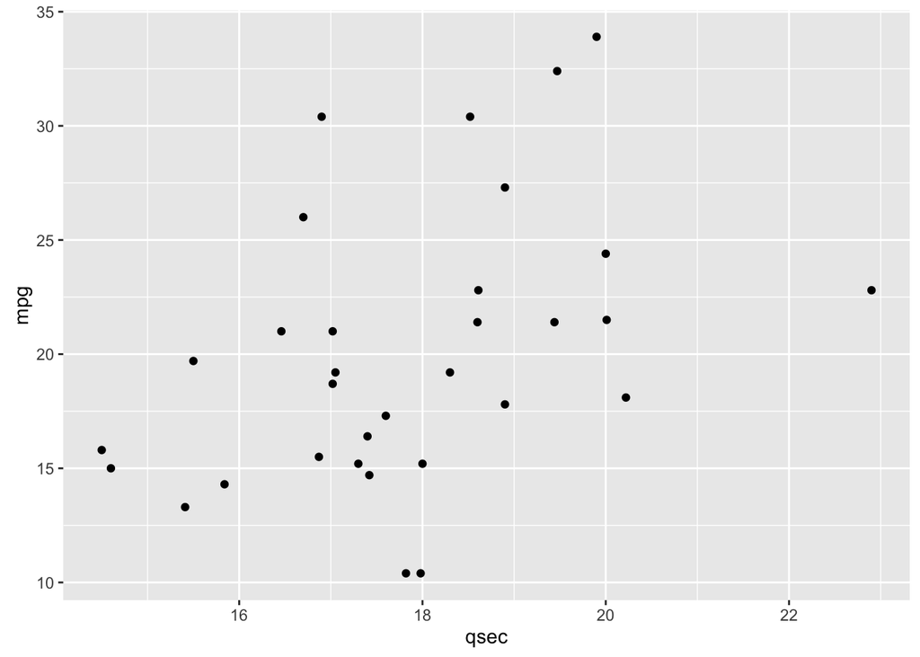

```r
library(ggplot2)
ggplot(mtcars, aes(qsec, mpg)) +
  geom_point()
```

A relationship between the two (faster cars get fewer miles per gallon) is certainly plausible, though not certain. To test this statistically, we might perform a linear regression:

```r
fit <- lm(mpg ~ qsec, mtcars)
```

We can display a linear fit using the default print method:

```r
fit
```

```
##
## Call:
## lm(formula = mpg ~ qsec, data = mtcars)
##
## Coefficients:
## (Intercept)         qsec
##      -5.114        1.412
```

This shows just the estimated intercept and slope. We can get a bit more information with summary:

```r
summary(fit)
```

```
##
## Call:
## lm(formula = mpg ~ qsec, data = mtcars)
##
## Residuals:
##     Min      1Q  Median      3Q     Max
## -9.8760 -3.4539 -0.7203  2.2774 11.6491
##
## Coefficients:
##             Estimate Std. Error t value Pr(>|t|)
## (Intercept)  -5.1140    10.0295  -0.510   0.6139
## qsec          1.4121     0.5592   2.525   0.0171 *
## ---
## Signif. codes:  0 '***' 0.001 '**' 0.01 '*' 0.05 '.' 0.1 ' ' 1
##
## Residual standard error: 5.564 on 30 degrees of freedom
## Multiple R-squared:  0.1753, Adjusted R-squared:  0.1478
## F-statistic: 6.377 on 1 and 30 DF,  p-value: 0.01708
```

This shows each of the estimates, standard errors, and p-values for the intercept and the slope. It also shows an overall $R^2$ value (variation in Y explained by X), and lots of other information.

One of the problems with these coefficients, however, is that it’s difficult to get out into a format that we can manipulate with dplyr, plot with ggplot2, or otherwise wrangle.

For that, we use the broom package:

```r
library(broom)
tidy(fit)
```

```
##          term  estimate  std.error  statistic    p.value
## 1 (Intercept) -5.114038 10.0295433 -0.5098974 0.61385436
## 2        qsec  1.412125  0.5592101  2.5252133 0.01708199
```

Notice that this is the same per-coefficient data that appears in the `summary(fit)` method. But instead of being displayed in a summary, it is in the form of

1. A data frame
2. Without rownames (they’ve been moved into the `term` column)
3. With names that do not have spaces or punctuation (besides `.`).

This makes the dataset ideal for further manipulation and recombination. broom works on many types of models (see the [README](https://github.com/dgrtwo/broom) for an extensive list), and all of its outputs are always in this form.

One more neat trick with `tidy` is that it extract the confidence intervals for each coefficient at the same time:

```r
tidy(fit, conf.int = TRUE)
```

```
##          term  estimate  std.error  statistic    p.value    conf.low
## 1 (Intercept) -5.114038 10.0295433 -0.5098974 0.61385436 -25.5970982
## 2        qsec  1.412125  0.5592101  2.5252133 0.01708199   0.2700654
##   conf.high
## 1 15.369022
## 2  2.554184
```

(See `help(tidy.lm)` for more that can be done with it).

`tidy` is one of the three tidying functions provided by broom. The other two are `augment` and `glance`:

```r
augmented <- augment(fit)

head(augmented)
```

```
##           .rownames  mpg  qsec  .fitted  .se.fit     .resid       .hat
## 1         Mazda RX4 21.0 16.46 18.12954 1.253181  2.8704634 0.05073341
## 2     Mazda RX4 Wag 21.0 17.02 18.92033 1.087258  2.0796735 0.03818847
## 3        Datsun 710 22.8 18.61 21.16561 1.071713  1.6343950 0.03710425
## 4    Hornet 4 Drive 21.4 19.44 22.33767 1.326337 -0.9376686 0.05682959
## 5 Hornet Sportabout 18.7 17.02 18.92033 1.087258 -0.2203265 0.03818847
## 6           Valiant 18.1 20.22 23.43913 1.650968 -5.3391260 0.08805303
##     .sigma      .cooksd  .std.resid
## 1 5.632343 7.493046e-03  0.52953086
## 2 5.645134 2.883894e-03  0.38113912
## 3 5.650392 1.726696e-03  0.29936481
## 4 5.656010 9.072558e-04 -0.17353524
## 5 5.658697 3.236851e-05 -0.04037897
## 6 5.562797 4.875085e-02 -1.00489051
```

The other, `glance`, gets out per-model values like R-squared (it’s not relevant for HW4 so we’re not going over it today).

### Graph within groups using do and tidy

Correlation does not imply causation. It’s entirely possible that `mpg` and `qsec` are both affected by another confounding factor.

Consider another column: `cyl`: this denotes the number of cylinders in the engine. Could this affect both acceleration and miles per gallon, such that their relationship otherwise disappears?

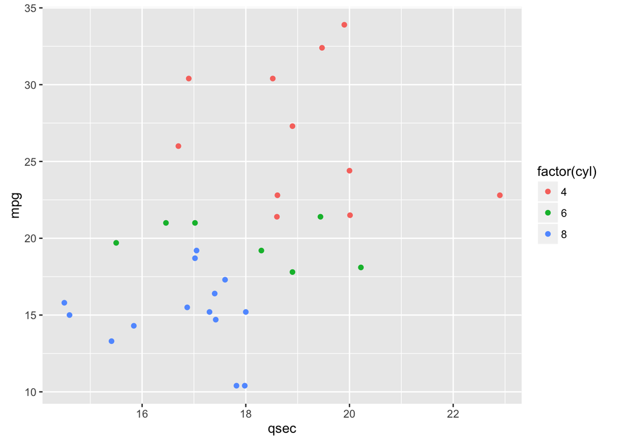

```r
ggplot(mtcars, aes(qsec, mpg, color = factor(cyl))) +
  geom_point()
```

That certainly looks like it might be a confounding factor: cars with more cylinders are faster but have less gas mileage.

Instead of performing one big regression, let’s perform a regression within each group defined by the number of cylinders. We can do that with dplyr’s `do`:

```r
library(dplyr)

fits <- mtcars %>%
  group_by(cyl) %>%
  do(mod = lm(mpg ~ qsec, data = .))

fits
```

```
## Source: local data frame [3 x 2]
## Groups: <by row>
##
##     cyl     mod
##   (dbl)   (chr)
## 1     4 <S3:lm>
## 2     6 <S3:lm>
## 3     8 <S3:lm>
```

The relevant expression is `lm(mpg ~ qsec, data = .)`- notice that we are performing the same regression as above, but this time we give `data = .`. The `.` means “the data frame within this current `group_by` group.

We now have a list column called `mod` that contains the three per-group fits. We can extract out the terms and coefficients using `tidy`, which has a nice shortcut for working with list columns:

```r
tidy(fits, mod)
```

```
## Source: local data frame [6 x 6]
## Groups: cyl [3]
##
##     cyl        term   estimate  std.error  statistic     p.value
##   (dbl)       (chr)      (dbl)      (dbl)      (dbl)       (dbl)
## 1     4 (Intercept) 38.7675611 16.6747428  2.3249271 0.045120364
## 2     4        qsec -0.6324791  0.8682778 -0.7284294 0.484871540
## 3     6 (Intercept) 26.1531490  6.2414336  4.1902471 0.008569752
## 4     6        qsec -0.3565801  0.3458536 -1.0310148 0.349801379
## 5     8 (Intercept) 18.8457155 10.3313237  1.8241337 0.093117425
## 6     8        qsec -0.2233296  0.6145320 -0.3634141 0.722617121
```

Notice that we’ve combined the three models, which each appear alongside a `cyl` showing what group they were in.

We can also extract out the `augment` results, such as the residuals and fitted values:

```r
augment(fits, mod)
```

```
## Source: local data frame [32 x 10]
## Groups: cyl [3]
##
##      cyl   mpg  qsec  .fitted  .se.fit     .resid       .hat   .sigma
##    (dbl) (dbl) (dbl)    (dbl)    (dbl)      (dbl)      (dbl)    (dbl)
## 1      4  22.8 18.61 26.99713 1.466158 -4.1971253 0.10073084 4.643181
## 2      4  24.4 20.00 26.11798 1.581503 -1.7179794 0.11720361 4.856939
## 3      4  22.8 22.90 24.28379 3.551607 -1.4837901 0.59108599 4.830606
## 4      4  32.4 19.47 26.45319 1.422492  5.9468067 0.09482016 4.373115
## 5      4  30.4 18.52 27.05405 1.492407  3.3459515 0.10436994 4.737643
## 6      4  33.9 19.90 26.18123 1.542274  7.7187727 0.11146121 3.952987
## 7      4  21.5 20.01 26.11165 1.585634 -4.6116546 0.11781671 4.581955
## 8      4  27.3 18.90 26.81371 1.408000  0.4862936 0.09289799 4.896445
## 9      4  26.0 16.70 28.20516 2.533466 -2.2051604 0.30076752 4.810246
## 10     4  30.4 16.90 28.07866 2.390317  2.3213354 0.26773912 4.804988
## ..   ...   ...   ...      ...      ...        ...        ...      ...
## Variables not shown: .cooksd (dbl), .std.resid (dbl)
```

Finally (this is important for the homework), note that this last result drops all the columns from the original data besides `cyl`, `mpg`, and `qsec` (the ones involved in the model or the grouping). What if we wanted to keep those alongside the residuals or fitted values?

We can fix this by doing two things: first, we remove the `mod =` in the original `do` statement- then we are no longer saving to a column, but rather expanding the data. Second, we add a `data = .` argument *to augment* alongside the `data = .` argument to `lm`- that tells augment to keep all the columns.

```r
augments <- mtcars %>%
  group_by(cyl) %>%
  do(augment(lm(mpg ~ qsec, data = .), data = .))

augments
```

```
## Source: local data frame [32 x 18]
## Groups: cyl [3]
##
##      mpg   cyl  disp    hp  drat    wt  qsec    vs    am  gear  carb
##    (dbl) (dbl) (dbl) (dbl) (dbl) (dbl) (dbl) (dbl) (dbl) (dbl) (dbl)
## 1   22.8     4 108.0    93  3.85 2.320 18.61     1     1     4     1
## 2   24.4     4 146.7    62  3.69 3.190 20.00     1     0     4     2
## 3   22.8     4 140.8    95  3.92 3.150 22.90     1     0     4     2
## 4   32.4     4  78.7    66  4.08 2.200 19.47     1     1     4     1
## 5   30.4     4  75.7    52  4.93 1.615 18.52     1     1     4     2
## 6   33.9     4  71.1    65  4.22 1.835 19.90     1     1     4     1
## 7   21.5     4 120.1    97  3.70 2.465 20.01     1     0     3     1
## 8   27.3     4  79.0    66  4.08 1.935 18.90     1     1     4     1
## 9   26.0     4 120.3    91  4.43 2.140 16.70     0     1     5     2
## 10  30.4     4  95.1   113  3.77 1.513 16.90     1     1     5     2
## ..   ...   ...   ...   ...   ...   ...   ...   ...   ...   ...   ...
## Variables not shown: .fitted (dbl), .se.fit (dbl), .resid (dbl), .hat
##   (dbl), .sigma (dbl), .cooksd (dbl), .std.resid (dbl)
```

Notice that all the columns from the original, like `disp`, `hp`, and `wt` are included now.